# HEIDI: ACHE

[figure not shown]

**Institution Profile**

**Classification:** Special Focus: Medical Schools and Centers

**Size:** Small

**Award Level Focus:** Graduate-focused

**UG Program Mix:** Not classified

**Grad Program Mix:** Special Focus: Medical Schools and Centers

**Research Activity:** No research designation

**Student Access & Earnings:** Not Classified in SAEC

**Top Degree Programs — 2025-26**

| Program | % of Degrees |
| --- | --- |
| Medicine. | 66.2% |
| Rehabilitation and Therapeutic Professions. | 22.1% |
| Biological and Biomedical Sciences, Other. | 11.7% |

**Location**

[interactive chart not shown]

#### Higher Education Institutional Data Interface (HEIDI)

HEIDI is a dashboard tool created by the Casagrande Institute to report data for institutions of higher education.

#### Casagrande Institute

The [Casagrande Institute](https://www.viterbo.edu/casagrande-institute/) helps institutions develop effective compensation practices for executives, faculty, and staff.

**David J. Bauer, Ph.D.**  
Director, Casagrande Institute  
djbauer@viterbo.edu  
608-796-3617  
[LinkedIn](https://www.linkedin.com/in/davidjbauer/)

**Group Overview**

- **A: IPEDS Auto**: Created by IPEDS in 2025-26 based on an internal grouping process involving Level, Control, Carnegie classification, and other variables.
- **B: IPEDS Auto Subset**: Subset of IPEDS Auto institutions with Expenses at or under $150M, based on the 2024-25 IPEDS data collection.
- **C: Suggested**: Private NFP institutions classified by Carnegie as Special Focus: Medical, Special Focus: Other Health, or Special Focus: Nursing, with Expenses from $25M to $125M, and at least 400 Doc Prof Prac FTE, based on the 2024-25 IPEDS data collection.
- **D: NFP Osteo / Medical**: Group of Private NFP institutions with Expenses up to $500M that satisfy one or more of the following criteria: 1. membership in the American Association of Colleges of Osteopathic Medicine (AACOM) per AACOM’s U.S. Osteopathic Medical Schools list (August 2026), 2. accreditation or pre-accreditation by the Commission on Osteopathic College Accreditation (COCA) per COCA’s Colleges of Osteopathic Medicine directory (May 2026), or 3. a 2025 Carnegie classification of “Special Focus: Medical Schools and Centers”. Osteopathic branch campuses and additional locations report under their IPEDS parent institution, except campuses IPEDS lists separately (Touro University Nevada and both Midwestern University campuses are included; KCU-Joplin reports no separate finance data and is covered by its parent, Kansas City University); VCOM reports as one institution covering all four campuses. COMs absent from IPEDS entirely (no Title IV participation) cannot be included: Noorda COM, Meritus SOM, Orlando COM, and The Valley COM. Excludes institutions in Puerto Rico.

**Group Membership**

| Institution | A: IPEDS Auto | B: IPEDS Auto Subset | C: Suggested | D: NFP Osteo / Medical |
| --- | --- | --- | --- | --- |
| A T Still University of Health Sciences | ✓ |  |  | ✓ |
| Alabama College of Osteopathic Medicine | ✓ | ✓ | ✓ | ✓ |
| Albany Medical College | ✓ |  |  |  |
| Baptist Health Sciences University |  |  |  | ✓ |
| California University of Science and Medicine | ✓ | ✓ |  |  |
| Campbell University |  |  |  | ✓ |
| Charles R Drew University of Medicine and Science |  |  |  | ✓ |
| D'Youville University |  |  | ✓ | ✓ |
| Des Moines University-Osteopathic Medical Center | ✓ | ✓ | ✓ | ✓ |
| Duquesne University |  |  |  | ✓ |

[output cut: 44 more lines]

**A: IPEDS Auto**

| Name | City | State | Zip | Carnegie | Research | Revenue 1 | Expenses 1 | FTE 2 | Endowment 1 |
| --- | --- | --- | --- | --- | --- | --- | --- | --- | --- |
| A T Still University of Health Sciences | Kirksville | MO | 63501 | Special Focus: Medical Schools and Centers | No research designation | 246784177 | 189842485 | 3894 | 136425451 |
| Alabama College of Osteopathic Medicine | Dothan | AL | 36303 | Special Focus: Medical Schools and Centers | No research designation | 48551065 | 35147162 | 789 | 217663 |
| Albany Medical College | Albany | NY | 12208 | Special Focus: Medical Schools and Centers | Research Colleges and Universities | 479805000 | 505460000 | 909 | 130749000 |
| Arkansas Colleges of Health Education | Fort Smith | AR | 72916 | Special Focus: Medical Schools and Centers | No research designation | 57982168 | 47269642 | 945 | 6636048 |
| California University of Science and Medicine | Colton | CA | 92324 | Special Focus: Graduate Studies | No research designation | 43139388 | 42561834 | 590 |  |
| Des Moines University-Osteopathic Medical Center | West Des Moines | IA | 50266 | Special Focus: Medical Schools and Centers | Research Colleges and Universities | 99479413 | 89508356 | 1638 | 177057947 |
| Edward Via College of Osteopathic Medicine | Blacksburg | VA | 24060 | Special Focus: Medical Schools and Centers | Research Colleges and Universities | 153360525 | 120866047 | 2617 | 31210043 |
| Geisinger Commonwealth School of Medicine | Scranton | PA | 18509 | Special Focus: Medical Schools and Centers | No research designation | 50098356 | 44681781 | 655 | 5959058 |
| Kansas City University | Kansas City | MO | 64106 | Special Focus: Medical Schools and Centers | No research designation | 144820393 | 98494227 | 2116 | 35910011 |
| Lake Erie College of Osteopathic Medicine | Erie | PA | 16509 | Special Focus: Medical Schools and Centers | No research designation | 270050867 | 124109207 | 4390 | 5029560 |

[output cut: 13 more lines]

**B: IPEDS Auto Subset**

| Name | City | State | Zip | Carnegie | Research | Revenue 1 | Expenses 1 | FTE 2 | Endowment 1 |
| --- | --- | --- | --- | --- | --- | --- | --- | --- | --- |
| Alabama College of Osteopathic Medicine | Dothan | AL | 36303 | Special Focus: Medical Schools and Centers | No research designation | 48551065 | 35147162 | 789 | 217663 |
| Arkansas Colleges of Health Education | Fort Smith | AR | 72916 | Special Focus: Medical Schools and Centers | No research designation | 57982168 | 47269642 | 945 | 6636048 |
| California University of Science and Medicine | Colton | CA | 92324 | Special Focus: Graduate Studies | No research designation | 43139388 | 42561834 | 590 |  |
| Des Moines University-Osteopathic Medical Center | West Des Moines | IA | 50266 | Special Focus: Medical Schools and Centers | Research Colleges and Universities | 99479413 | 89508356 | 1638 | 177057947 |
| Edward Via College of Osteopathic Medicine | Blacksburg | VA | 24060 | Special Focus: Medical Schools and Centers | Research Colleges and Universities | 153360525 | 120866047 | 2617 | 31210043 |
| Geisinger Commonwealth School of Medicine | Scranton | PA | 18509 | Special Focus: Medical Schools and Centers | No research designation | 50098356 | 44681781 | 655 | 5959058 |
| Kansas City University | Kansas City | MO | 64106 | Special Focus: Medical Schools and Centers | No research designation | 144820393 | 98494227 | 2116 | 35910011 |
| Lake Erie College of Osteopathic Medicine | Erie | PA | 16509 | Special Focus: Medical Schools and Centers | No research designation | 270050867 | 124109207 | 4390 | 5029560 |
| New York Medical College | Valhalla | NY | 10595 | Special Focus: Medical Schools and Centers | Research Colleges and Universities | 128228436 | 117714575 | 1469 | 81415365 |
| Pacific Northwest University of Health Sciences | Yakima | WA | 98901 | Special Focus: Medical Schools and Centers | No research designation | 50719884 | 43709889 | 698 | 2641142 |

[output cut: 4 more lines]

**C: Suggested**

| Name | City | State | Zip | Carnegie | Research | Revenue 1 | Expenses 1 | FTE 2 | Endowment 1 |
| --- | --- | --- | --- | --- | --- | --- | --- | --- | --- |
| Alabama College of Osteopathic Medicine | Dothan | AL | 36303 | Special Focus: Medical Schools and Centers | No research designation | 48551065 | 35147162 | 789 | 217663 |
| Arkansas Colleges of Health Education | Fort Smith | AR | 72916 | Special Focus: Medical Schools and Centers | No research designation | 57982168 | 47269642 | 945 | 6636048 |
| D'Youville University | Buffalo | NY | 14201 | Special Focus: Other Health Professions | No research designation | 86480172 | 95298826 | 2242 | 22307551 |
| Des Moines University-Osteopathic Medical Center | West Des Moines | IA | 50266 | Special Focus: Medical Schools and Centers | Research Colleges and Universities | 99479413 | 89508356 | 1638 | 177057947 |
| Edward Via College of Osteopathic Medicine | Blacksburg | VA | 24060 | Special Focus: Medical Schools and Centers | Research Colleges and Universities | 153360525 | 120866047 | 2617 | 31210043 |
| Frontier Nursing University | Versailles | KY | 40383 | Special Focus: Nursing | No research designation | 54178168 | 41632008 | 1754 | 23871503 |
| Geisinger Commonwealth School of Medicine | Scranton | PA | 18509 | Special Focus: Medical Schools and Centers | No research designation | 50098356 | 44681781 | 655 | 5959058 |
| Hackensack Meridian School of Medicine | Nutley | NJ | 07110 | Special Focus: Medical Schools and Centers | No research designation | 59413187 | 37958759 | 612 | 142923967 |
| Illinois College of Optometry | Chicago | IL | 60616 | Special Focus: Other Health Professions | No research designation | 38808821 | 35843328 | 510 | 1960971 |
| Kansas City University | Kansas City | MO | 64106 | Special Focus: Medical Schools and Centers | No research designation | 144820393 | 98494227 | 2116 | 35910011 |

[output cut: 17 more lines]

**D: NFP Osteo / Medical**

| Name | City | State | Zip | Carnegie | Research | Revenue 1 | Expenses 1 | FTE 2 | Endowment 1 |
| --- | --- | --- | --- | --- | --- | --- | --- | --- | --- |
| A T Still University of Health Sciences | Kirksville | MO | 63501 | Special Focus: Medical Schools and Centers | No research designation | 246784177 | 189842485 | 3894 | 136425451 |
| Alabama College of Osteopathic Medicine | Dothan | AL | 36303 | Special Focus: Medical Schools and Centers | No research designation | 48551065 | 35147162 | 789 | 217663 |
| Arkansas Colleges of Health Education | Fort Smith | AR | 72916 | Special Focus: Medical Schools and Centers | No research designation | 57982168 | 47269642 | 945 | 6636048 |
| Baptist Health Sciences University | Memphis | TN | 38104 | Special Focus: Nursing | No research designation | 34109038 | 30432074 | 963 | 91778586 |
| Campbell University | Buies Creek | NC | 27506 | Professions-focused Undergraduate/Graduate-Doctorate Medium | No research designation | 186676855 | 161912512 | 5066 | 210406971 |
| Charles R Drew University of Medicine and Science | Los Angeles | CA | 90059 | Special Focus: Medical Schools and Centers | Research Colleges and Universities | 95118100 | 96581000 | 1360 | 109922800 |
| D'Youville University | Buffalo | NY | 14201 | Special Focus: Other Health Professions | No research designation | 86480172 | 95298826 | 2242 | 22307551 |
| Des Moines University-Osteopathic Medical Center | West Des Moines | IA | 50266 | Special Focus: Medical Schools and Centers | Research Colleges and Universities | 99479413 | 89508356 | 1638 | 177057947 |
| Duquesne University | Pittsburgh | PA | 15282 | Professions-focused Undergraduate/Graduate-Doctorate Medium | Research 2: High Spending and Doctorate Production | 382314000 | 323172000 | 8303 | 661012000 |
| Edward Via College of Osteopathic Medicine | Blacksburg | VA | 24060 | Special Focus: Medical Schools and Centers | Research Colleges and Universities | 153360525 | 120866047 | 2617 | 31210043 |

[output cut: 30 more lines]

**A: IPEDS Auto**

**Financial and Student Positioning of ACHE Within the A: IPEDS Auto Group**

[output not shown]

<sup>1</sup> Data from the 2024-25 IPEDS collection.  
<sup>2</sup> Data from the 2025-26 IPEDS collection.  
Group values exclude data from ACHE.

**B: IPEDS Auto Subset**

**Financial and Student Positioning of ACHE Within the B: IPEDS Auto Subset Group**

[output not shown]

<sup>1</sup> Data from the 2024-25 IPEDS collection.  
<sup>2</sup> Data from the 2025-26 IPEDS collection.  
Group values exclude data from ACHE.

**C: Suggested**

**Financial and Student Positioning of ACHE Within the C: Suggested Group**

| Metric | **C: Suggested Group** n | **C: Suggested Group** Min | **C: Suggested Group** p25 | **C: Suggested Group** Median | **C: Suggested Group** p75 | **C: Suggested Group** Max | Spread | **ACHE** ACHE | **ACHE** Percentile | **ACHE** % of Median |
| --- | --- | --- | --- | --- | --- | --- | --- | --- | --- | --- |
| Revenue<sup>1</sup> | 26 | 21.3M | 45.0M | 64.5M | 96.3M | 270.1M |  | 58.0M | 46 | 90% |
| Revenue from Tuition and Fees<sup>1</sup> | 26 | 14.2M | 31.1M | 48.1M | 66.8M | 165.2M |  | 36.7M | 34 | 76% |
| Expenses<sup>1</sup> | 26 | 26.6M | 38.3M | 65.0M | 93.9M | 124.1M |  | 47.3M | 42 | 73% |
| Expenses: Research<sup>1</sup> | 26 | 0.0 | 582.7k | 1.5M | 3.2M | 21.4M |  | 1.3M | 47 | 88% |
| Margin<sup>1</sup> | 26 | −98.5M | 3.0M | 6.9M | 13.3M | 145.9M |  | 10.7M | 64 | 156% |
| Endowment<sup>1</sup> | 24 | 217.7k | 5.7M | 27.5M | 58.3M | 1.0B |  | 6.6M | 31 | 24% |
| 12-Month Unduplicated Headcount<sup>2</sup> | 26 | 522 | 719 | 1,634 | 2,548 | 5,246 |  | 941 | 33 | 58% |
| Undergrad FTE<sup>2</sup> | 12 | 5 | 60 | 374 | 653 | 1,159 |  | -- | -- | -- |
| Grad FTE<sup>2</sup> | 22 | 0 | 95 | 240 | 671 | 1,381 |  | 70 | 17 | 29% |
| Doc Prof Prac FTE<sup>2</sup> | 26 | 373 | 524 | 707 | 1,151 | 4,041 |  | 875 | 64 | 124% |
| Total FTE<sup>2</sup> | 26 | 0 | 666 | 1,554 | 2,060 | 4,390 |  | 945 | 38 | 61% |
| Program Breadth (distinct 4-digit CIPs)<sup>2</sup> | 26 | 1 | 2 | 4 | 9 | 22 |  | 3 | 36 | 67% |
| Top 5 Programs % of Completions<sup>2</sup> | 26 | 75 | 93 | 100 | 100 | 100 |  | 100 | 74 | 100% |
| Distinct Award Levels Offered<sup>2</sup> | 26 | 1 | 2 | 3 | 5 | 7 |  | 2 | 28 | 67% |

<sup>1</sup> Data from the 2024-25 IPEDS collection.  
<sup>2</sup> Data from the 2025-26 IPEDS collection.  
Group values exclude data from ACHE.

**D: NFP Osteo / Medical**

**Financial and Student Positioning of ACHE Within the D: NFP Osteo / Medical Group**

| Metric | **D: NFP Osteo / Medical Group** n | **D: NFP Osteo / Medical Group** Min | **D: NFP Osteo / Medical Group** p25 | **D: NFP Osteo / Medical Group** Median | **D: NFP Osteo / Medical Group** p75 | **D: NFP Osteo / Medical Group** Max | Spread | **ACHE** ACHE | **ACHE** Percentile | **ACHE** % of Median |
| --- | --- | --- | --- | --- | --- | --- | --- | --- | --- | --- |
| Revenue<sup>1</sup> | 39 | 16.2M | 82.5M | 153.4M | 258.4M | 438.9M |  | 58.0M | 15 | 38% |
| Revenue from Tuition and Fees<sup>1</sup> | 39 | 12.7M | 48.2M | 86.2M | 166.7M | 303.8M |  | 36.7M | 20 | 43% |
| Expenses<sup>1</sup> | 39 | 26.0M | 86.3M | 124.1M | 193.8M | 426.2M |  | 47.3M | 13 | 38% |
| Expenses: Research<sup>1</sup> | 39 | 0.0 | 424.2k | 3.4M | 14.4M | 68.9M |  | 1.3M | 36 | 39% |
| Margin<sup>1</sup> | 39 | −98.5M | 6.6M | 19.1M | 39.4M | 145.9M |  | 10.7M | 37 | 56% |
| Endowment<sup>1</sup> | 37 | 217.7k | 34.0M | 85.6M | 177.1M | 1.0B |  | 6.6M | 15 | 8% |
| 12-Month Unduplicated Headcount<sup>2</sup> | 39 | 358 | 1,260 | 2,625 | 4,859 | 14,570 |  | 941 | 15 | 36% |
| Undergrad FTE<sup>2</sup> | 22 | 5 | 409 | 1,231 | 3,228 | 5,668 |  | -- | -- | -- |
| Grad FTE<sup>2</sup> | 35 | 8 | 365 | 710 | 974 | 3,714 |  | 70 | 5 | 10% |
| Doc Prof Prac FTE<sup>2</sup> | 39 | 94 | 554 | 994 | 1,884 | 4,041 |  | 875 | 44 | 88% |
| Total FTE<sup>2</sup> | 39 | 360 | 1,296 | 2,277 | 4,310 | 10,992 |  | 945 | 16 | 42% |
| Program Breadth (distinct 4-digit CIPs)<sup>2</sup> | 38 | 1 | 6 | 11 | 36 | 62 |  | 3 | 12 | 27% |
| Top 5 Programs % of Completions<sup>2</sup> | 38 | 39 | 64 | 82 | 100 | 100 |  | 100 | 88 | 121% |
| Distinct Award Levels Offered<sup>2</sup> | 38 | 1 | 3 | 5 | 6 | 10 |  | 2 | 12 | 40% |

<sup>1</sup> Data from the 2024-25 IPEDS collection.  
<sup>2</sup> Data from the 2025-26 IPEDS collection.  
Group values exclude data from ACHE.

**A: IPEDS Auto**

**Revenue**

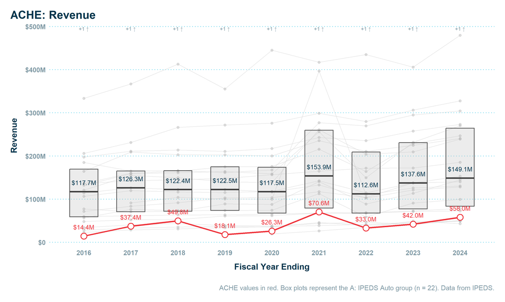

**Revenue from Tuition and Fees**

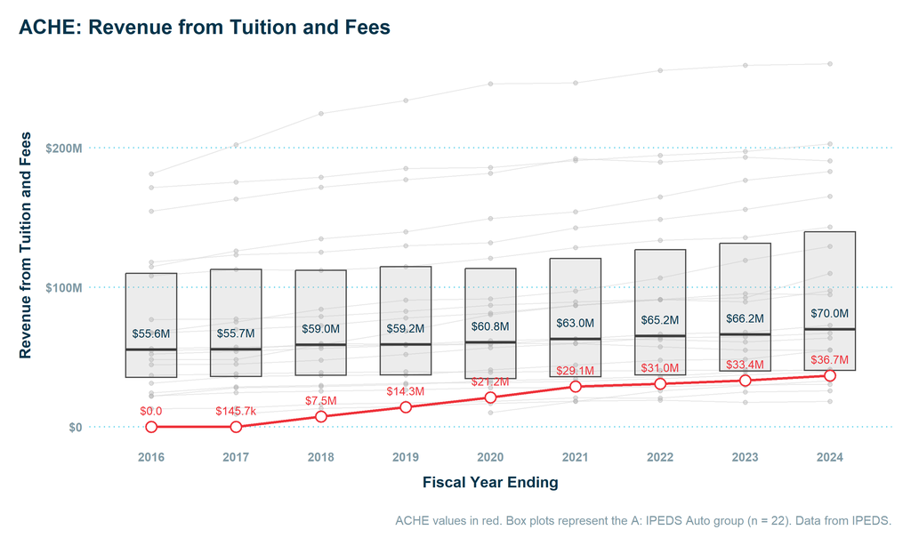

**Expenses**

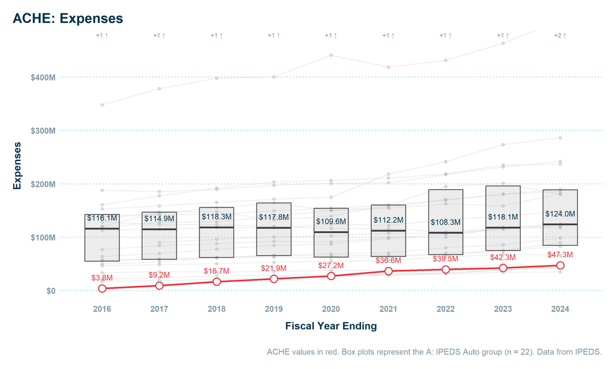

**Expenses: Research**

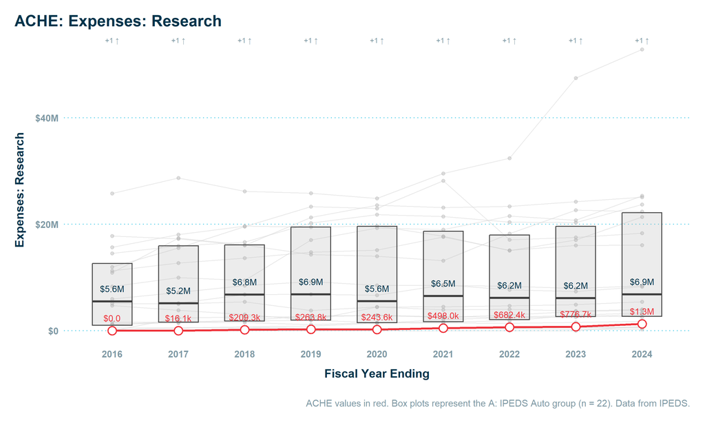

**Margin**

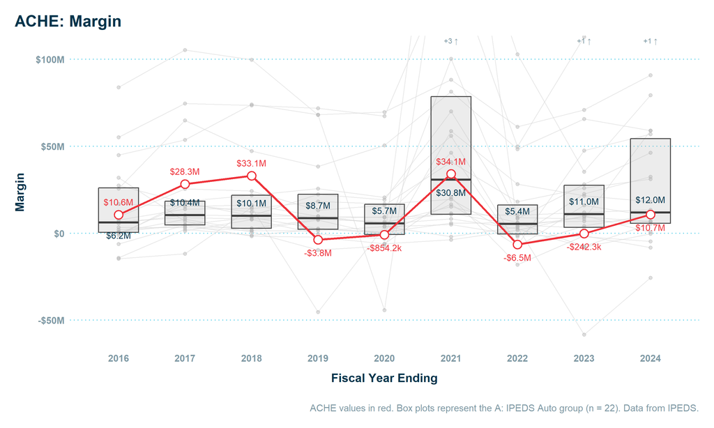

**Endowment**

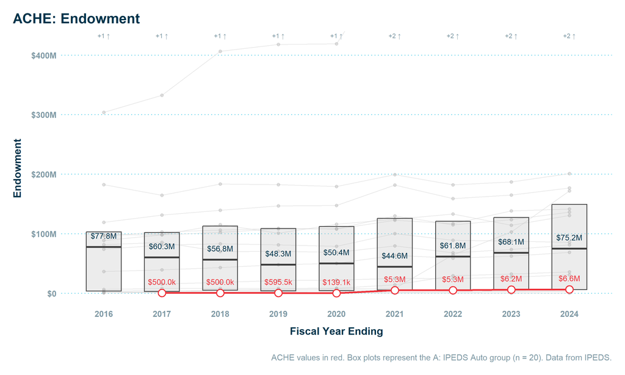

**12-Month Unduplicated Headcount**

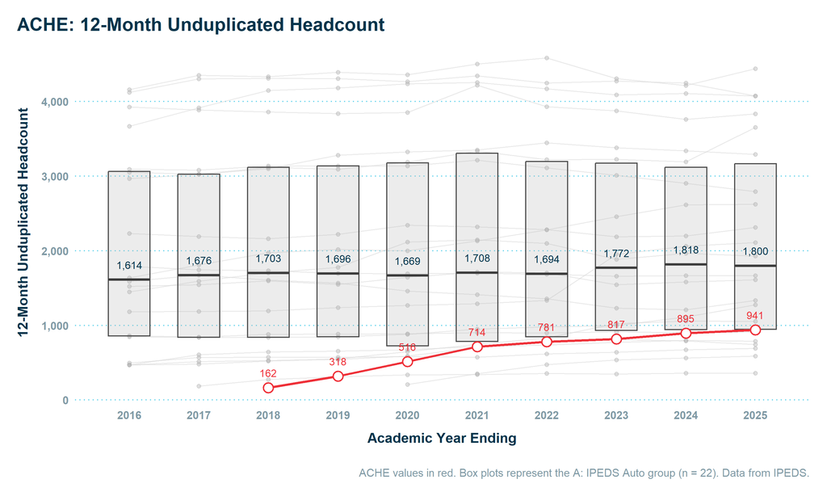

**Undergrad FTE**

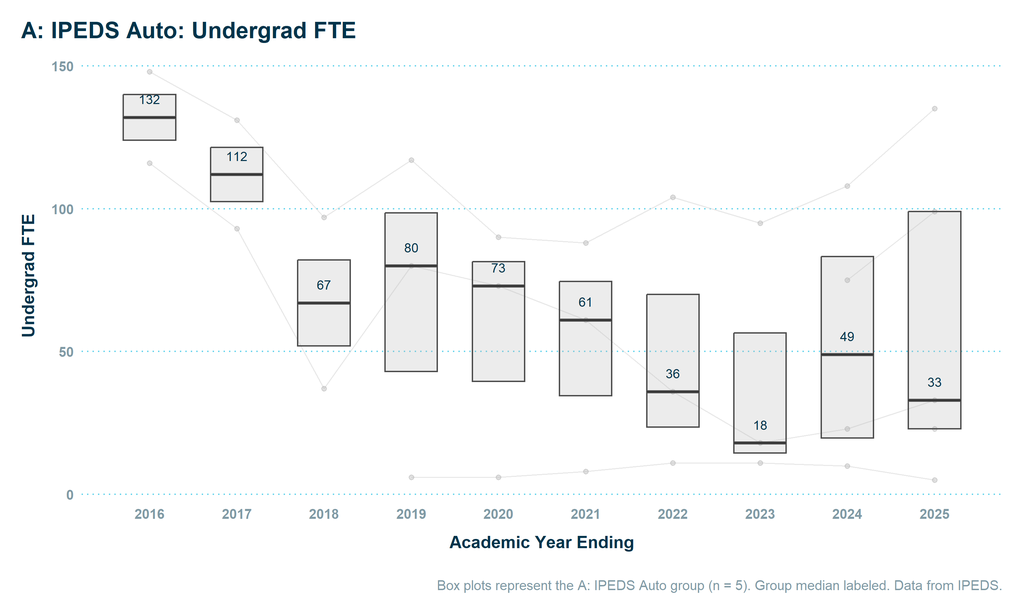

**Grad FTE**

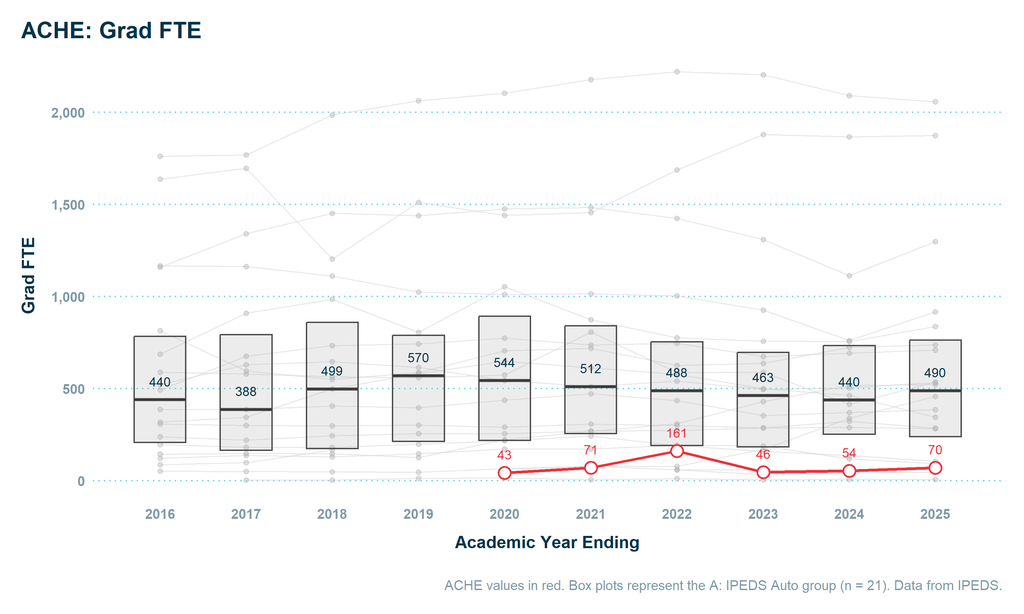

**Doc Prof Prac FTE**

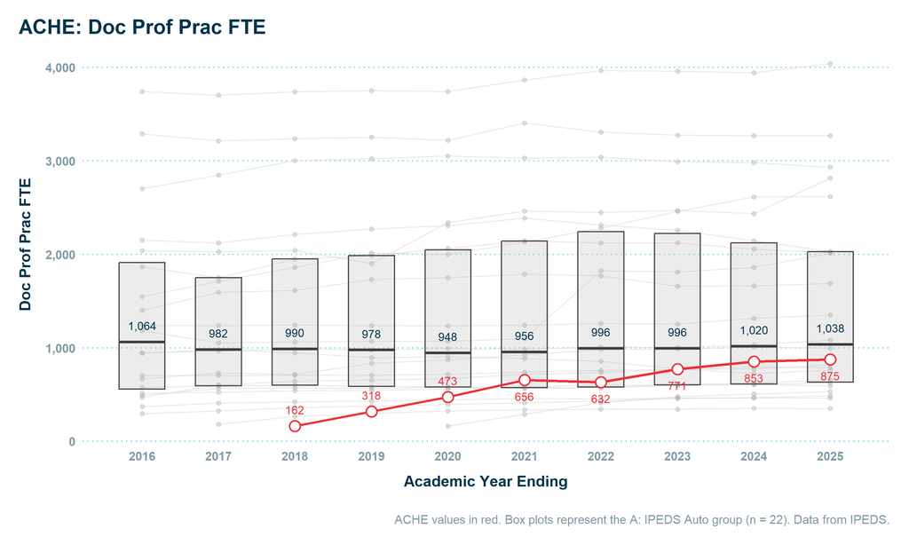

**Total FTE**

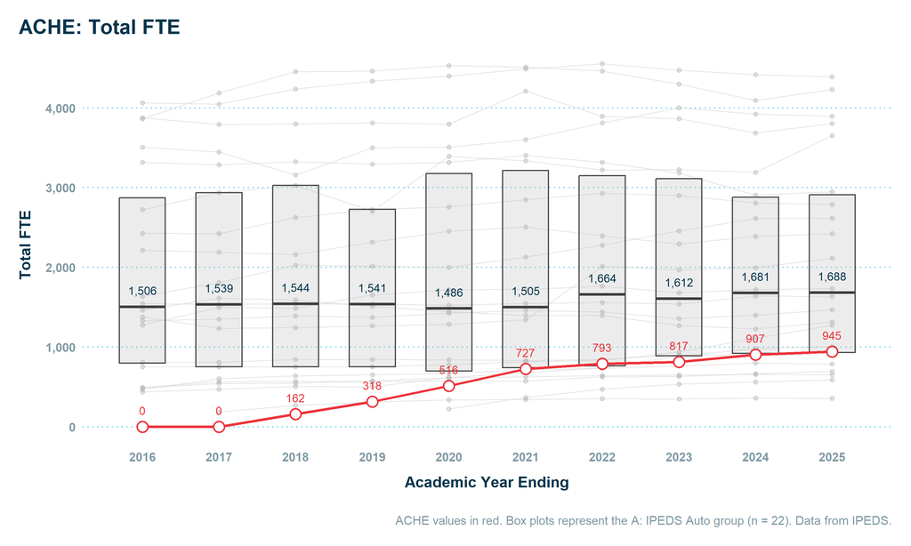

**Program Breadth (distinct 4-digit CIPs)**

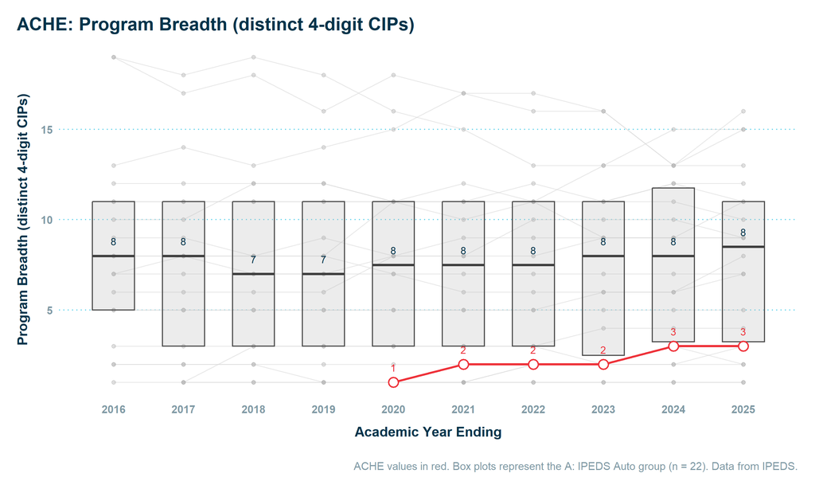

**Top 5 Programs % of Completions**

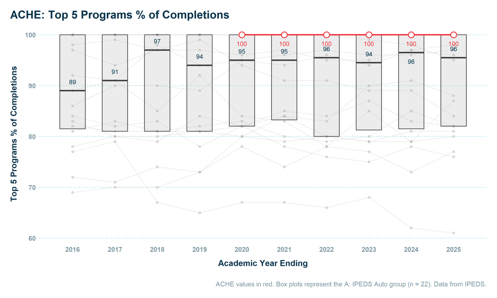

**Distinct Award Levels Offered**

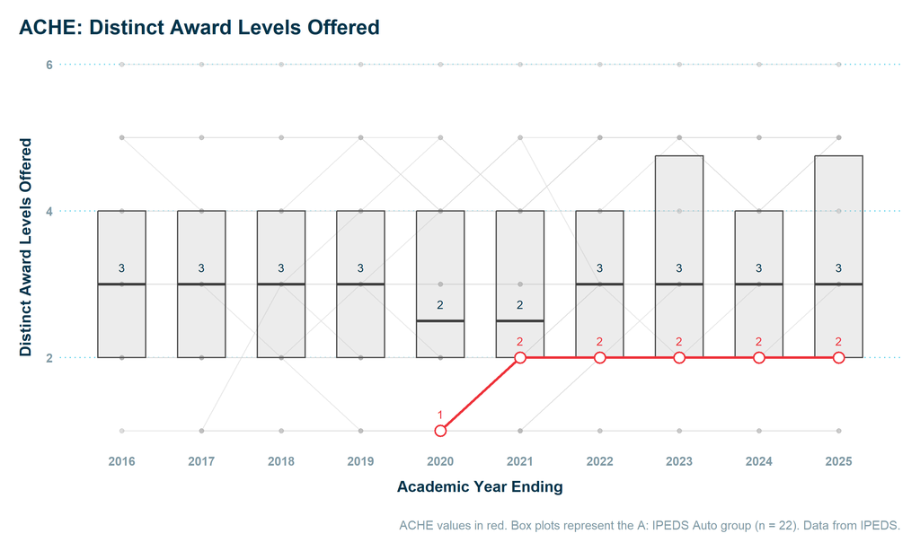

**B: IPEDS Auto Subset**

**Revenue**

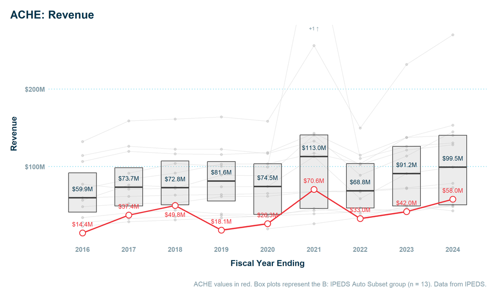

**Revenue from Tuition and Fees**

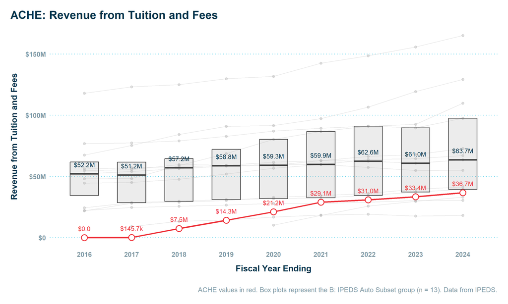

**Expenses**

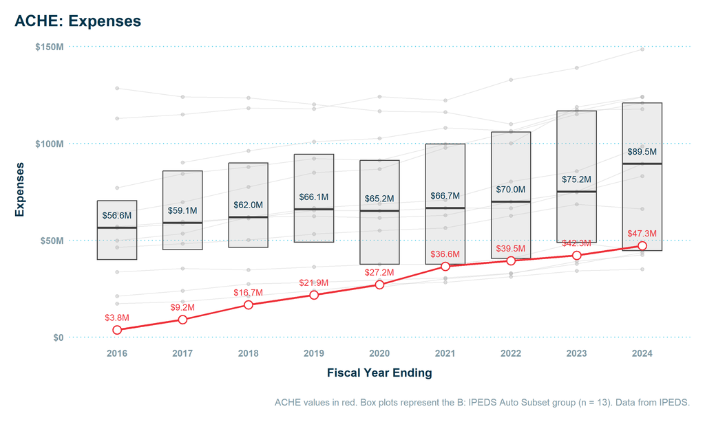

**Expenses: Research**

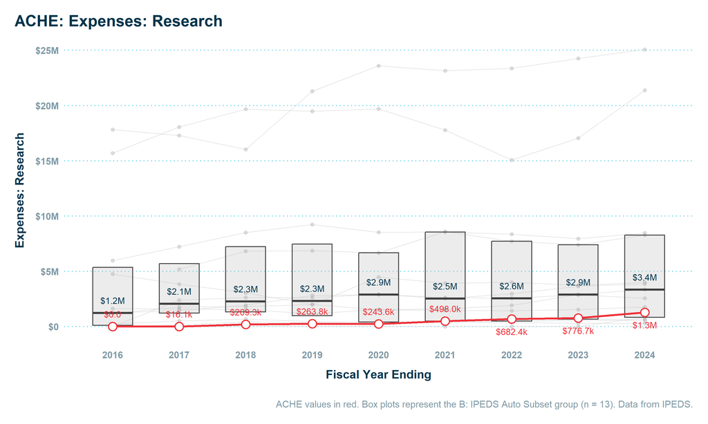

**Margin**

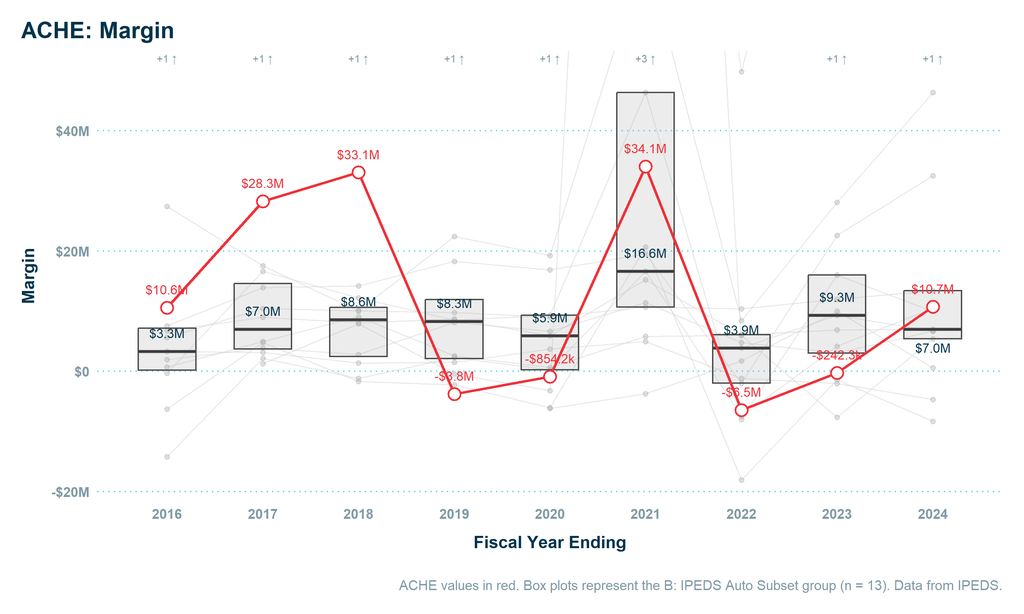

**Endowment**

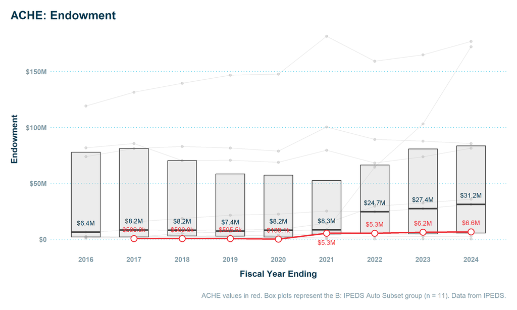

**12-Month Unduplicated Headcount**

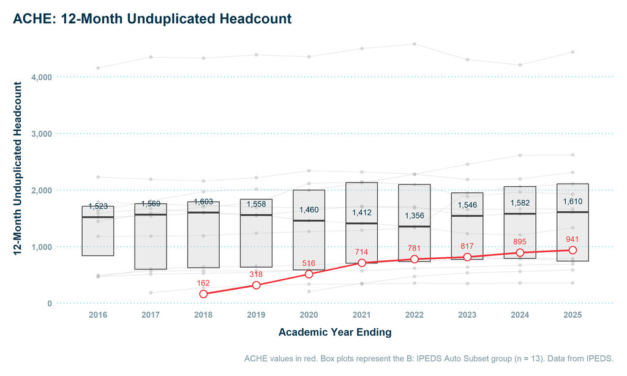

**Undergrad FTE**

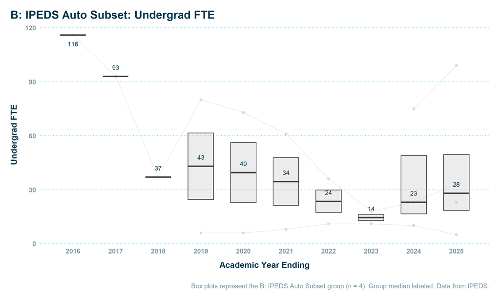

**Grad FTE**

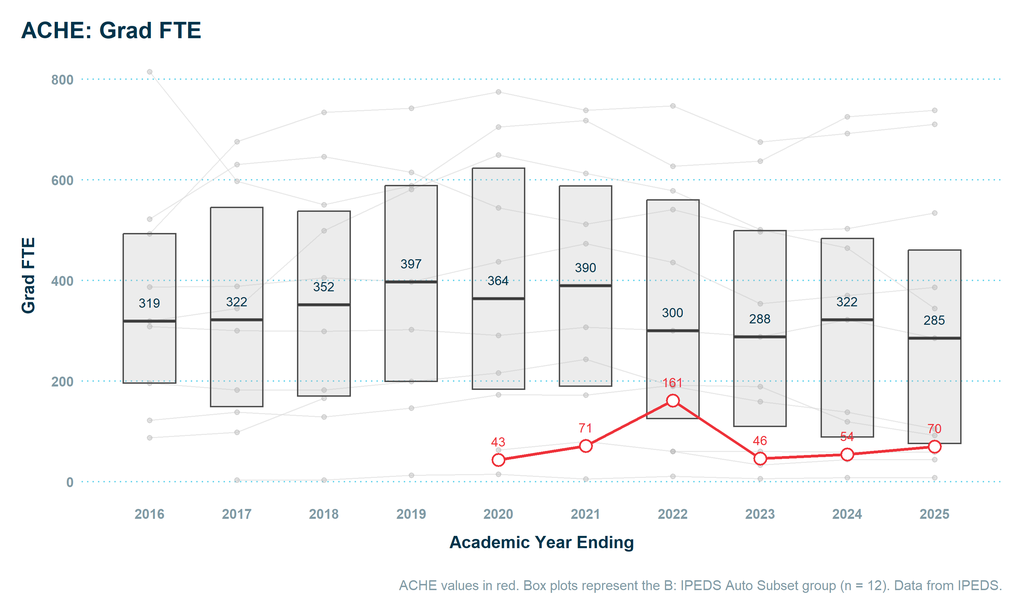

**Doc Prof Prac FTE**

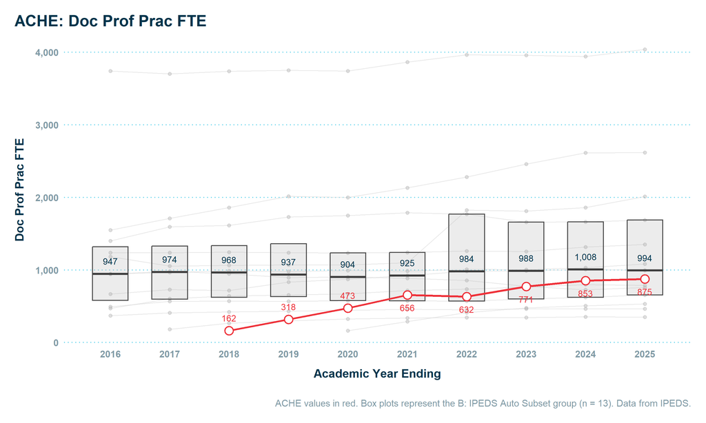

**Total FTE**

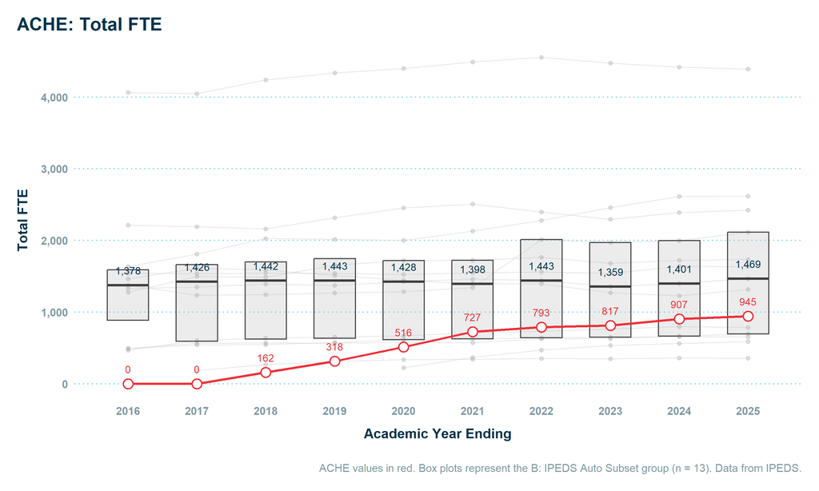

**Program Breadth (distinct 4-digit CIPs)**

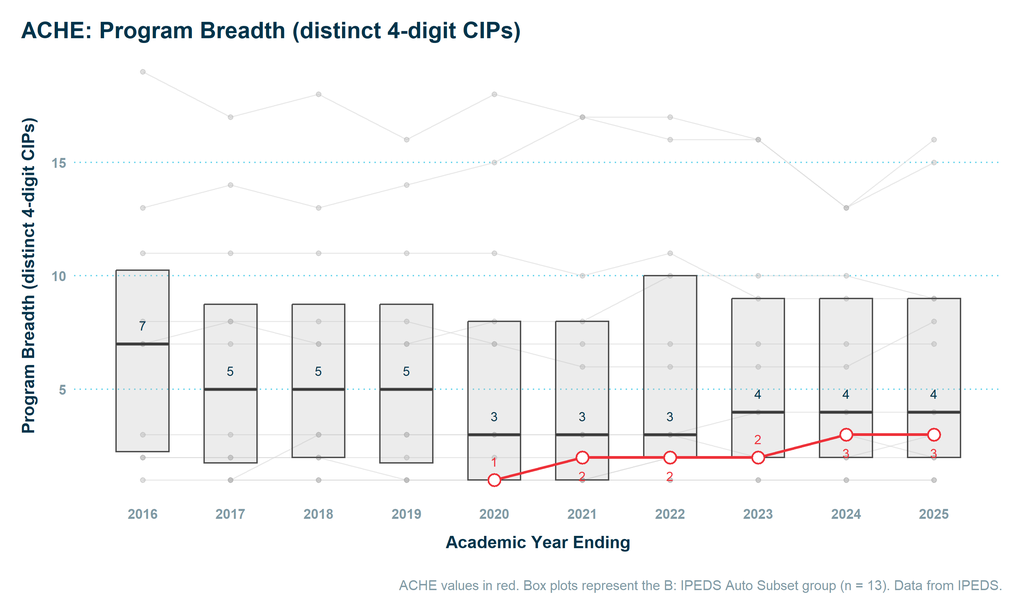

**Top 5 Programs % of Completions**